# A Guide to Data Analysis using R

by [Myo Minn Oo](https://myominnoo.github.io/) - last updated on 05 September 2020

### 0.0.1 Model Diagnostics

So far, we have learned how to run linear regression in R, with some methods of checking the data. Unless we verify that our data meet the assumptions under linear regression, the results may be misleading. In this section, we will explore how we can use R to check whether our data satisfy the assumptions. This section was based on UCLA’s `STATA` tutorial series.[^1]

We will focus on the following assumptions.

```
- Linearity
      The relationships between the predictors and the outcome variable should be linear.
- Normality
      The errors should be normally distributed – technically normality is necessary only for hypothesis tests to be valid, estimation of the coefficients only requires that the errors be identically and independently distributed
- Homogeneity of variance (homoscedasticity)
      The error variance should be constant
- Independence
      The errors associated with one observation are not correlated with the errors of any other observation.
```

In this section, we use an example dataset called `crime`. This dataset is from Statistical Methods for Social Sciences, Third Edition by Alan Agresti, and Barbara Finlay (Prentice Hall, 1997). Detail can be read here.[^2]

Variables

1. sid - id
2. state - state name
3. crime - violent crimes per 100,000 people
4. murder - murders per 1,000,000
5. pctmetro - the percentage of the population living in metropolitan areas
6. pctwhite - the percentage of the white population
7. pcths - the percentage of the population with high school education and above
8. poverty - the percentage of the population living under the poverty line
9. single - the percentage of the population that are single parents

We want to predict `crime` based on `pctmetro`, `poverty`, and `single`. That is to say, we want to build a linear regression model between the response variable `crime` and the independent variables `pctmetro`, `poverty`, and `single`.

First, let’s import this dataset into R.

```r
## Import crime dataset
crime <- haven::read_dta("https://stats.idre.ucla.edu/stat/stata/webbooks/reg/crime.dta")

## Check the dataset
codebook(crime)
```

```
#> ________________________________________________________________
#>
#> Codebook: 'crime'
#> ________________________________________________________________
#>
#>  No Variable |              Label      Type Obs_Num <NA> <NA>(%)
#>  -- -------- + ------------------ --------- ------- ---- -------
#>   1      sid |               <NA>   numeric      51    0       0
#>   2    state |               <NA> character      51    0       0
#>   3    crime | violent crime rate   numeric      51    0       0
#>   4   murder |        murder rate   numeric      51    0       0
#>   5 pctmetro |   pct metropolitan   numeric      51    0       0
#>   6 pctwhite |          pct white   numeric      51    0       0
#>   7    pcths |   pct hs graduates   numeric      51    0       0
#>   8  poverty |        pct poverty   numeric      51    0       0
#>   9   single |  pct single parent   numeric      51    0       0
#>  -- -------- + ------------------ --------- ------- ---- -------
#> ________________________________________________________________
#> (Dataset Label: crime data from agresti & finlay - 1997)
```

#### 0.0.1.1 Outliers and influential data

Often you deal with a dataset where a single observation can make a huge difference in the regression output if it is substantially different from all other observations. In this case, you need to investigate this further. There are three ways that observations can be unusually different.

1. Outliers

They are **large residuals** in linear regression. An outlier often represents data entry error.

2. Leverage points

An extreme value in a predictor variable is called high leverage point.

3. Influential points

If removing such extreme values or high leverage points substantially changes the coefficient estimates, such values are called influential points.

Let’s create a scatter plot matrix on variables, `crime`, `pctmetro`, `poverty`, and `single`.

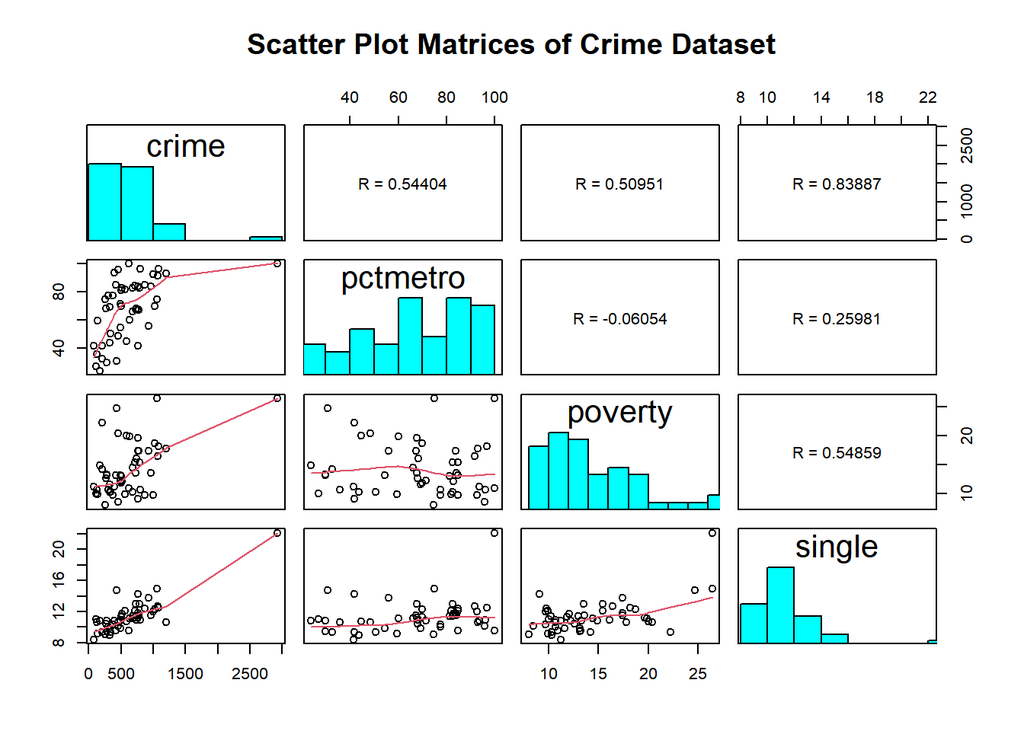

```r
## Scatter plot matrices
crime %>%
  select(crime, pctmetro, poverty, single) %>%
  scatterPlotMatrix(main = "Scatter Plot Matrices of Crime Dataset")
```

We see a data point that is far away from the rest of the data in every plot. Let’s make individual plots so that we can get a better view. We also add labels to these data points so that we know which state these data points come from.

Below we use `text` function from base R to add labels to the data points. Check the help page by running `?text`.

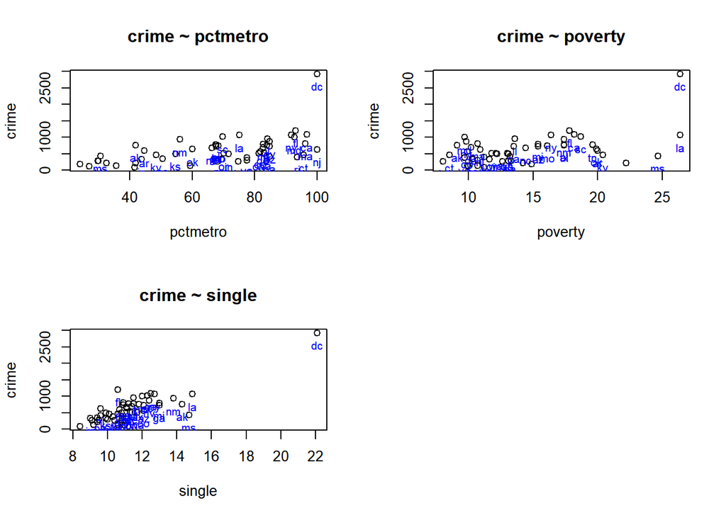

```r
## Set graphs parameter
par(mfrow = c(2, 2))

## Plot crime and pctmetro
plot(crime ~ pctmetro, data = crime, main = "crime ~ pctmetro")
crime %$% text(crime ~ pctmetro, labels = state,
               cex = 0.8, pos = 1, col = "blue")

## Plot crime and poverty
plot(crime ~ poverty, data = crime, main = "crime ~ poverty")
crime %$% text(crime ~ poverty, labels = state,
               cex = 0.8, pos = 1, col = "blue")

## Plot crime and single
plot(crime ~ single, data = crime, main = "crime ~ single")
crime %$% text(crime ~ single, labels = state,
               cex = 0.8, pos = 1, col = "blue")

## Reset graphs parameter
par(mfrow = c(1, 1))
```

We see the data point that is far away from the rest of the data comes from `DC` state. Since it stands out, we can say this is an outlier and leverage point. We keep this in mind while we continue fitting the linear model.

Let’s fit the model and run `regress`.

```r
## Fit the model
fit <- lm(crime ~ pctmetro + poverty + single, data = crime)

## Generate regression output
## Set decimal point to 2 to make the output fit the page width
reg <- regress(fit, rnd = 2)
```

```
#> _________________________________________________________________________
#>
#>                 Linear Regression Output
#> _________________________________________________________________________
#>
#>          Stats |    Value             Source |    DF         SS        MS
#>  ------------- + --------         ---------- + ----- ---------- ---------
#>  Number of Obs |       51              Model |     3  8170480.2 2723493.4
#>       F(3, 47) |    82.16           Residual |    47  1557994.5   33148.8
#>       Prob > F |     0.00         ---------- + ----- ---------- ---------
#>      R-Squared |     0.84              Total |    50  9728474.7  194569.5
#>  Adj R-Squared |     0.83
#>            AIC |   681.41                              Root MSE    182.07
#>  ------------- + -------- ------- ------------ ----- ---------- ---------
#>          crime |    Coef. Std.Err            t P>|t| [95% Conf. Interval]
#>  ------------- + -------- ------- ------------ ----- ---------- ---------
#>       pctmetro |     7.83    1.25         6.24  0.00       5.37     10.29
#>        poverty |    17.68    6.94         2.55  0.01       4.08     31.28
#>         single |   132.41   15.50         8.54  0.00     102.02    162.79
#>    (Intercept) | -1666.44  147.85       -11.27  0.00   -1956.23  -1376.65
#>  ------------- + -------- ------- ------------ ----- ---------- ---------
#> _________________________________________________________________________
#> (Fit: lm(formula = crime ~ pctmetro + poverty + single, data = crime))
#> (pctmetro: pct metropolitan)
#> (poverty: pct poverty)
#> (single: pct single parent)
#> (crime: violent crime rate)
```

Next, we are going to generate studentized residuals, leverage values, and Cook’s distance values from the model to identify the potentially unusual or influential points.

Below we use `predict` function to generate the data with these statistics, and store the result to `rstd`.

```r
## Generate diagnostic statistics
rstd <- predict(reg)

## Check the dataset
codebook(rstd)
```

```
#> _____________________________________________________________________
#>
#> Codebook: 'rstd'
#> _____________________________________________________________________
#>
#>  No  Variable |                  Label      Type Obs_Num <NA> <NA>(%)
#>  -- --------- + ---------------------- --------- ------- ---- -------
#>   1     crime |                   <NA>   numeric      51    0       0
#>   2  pctmetro |                   <NA>   numeric      51    0       0
#>   3   poverty |                   <NA>   numeric      51    0       0
#>   4    single |                   <NA>   numeric      51    0       0
#>   5       sid |                   <NA>   numeric      51    0       0
#>   6     state |                   <NA> character      51    0       0
#>   7    murder |                   <NA>   numeric      51    0       0
#>   8  pctwhite |                   <NA>   numeric      51    0       0
#>   9     pcths |                   <NA>   numeric      51    0       0
#>  10    fitted |          Fitted values   numeric      51    0       0
#>  11     resid |              Residuals   numeric      51    0       0
#>  12 std.resid |  Studentized Residuals   numeric      51    0       0
#>  13       hat | Leverage or hat values   numeric      51    0       0
#>  14     sigma |              hat sigma   numeric      51    0       0
#>  15    cooksd |        Cook's Distance   numeric      51    0       0
#>  -- --------- + ---------------------- --------- ------- ---- -------
#> _____________________________________________________________________
```

The studentized residuals are stored under the variable, `std.resid`, leverage under `hat` and Cook’s distance under `cooksd`. Let’s check the studentized residuals with `boxplot`.

[figure not shown]

```r
## Set graphs parameter
par(mfrow = c(1, 3))

## Boxplot
rstd %$% boxplot(std.resid, main = "Studentized Residuals")
rstd %$% boxplot(std.resid, main = "Leverage values")
rstd %$% boxplot(std.resid, main = "Cook's Distance")
```

```r
## Set graphs parameter
par(mfrow = c(1, 1))
```

**Studentized Residuals**

We want to see which state has studentized residuals over +2 or under -2. We do this by listing a few lines from the top and the bottom. We use `head` and `tail` functions from base R to get top and bottom rows.

```r
## Check top rows
rstd %>%
  arrange(std.resid) %>%
  select(sid, state, std.resid) %>%
  head
```

```
#>   sid state std.resid
#> 1  25    ms -3.193796
#> 2  18    la -1.793716
#> 3  39    ri -1.653521
#> 4  47    wa -1.294313
#> 5  35    oh -1.144457
#> 6  48    wi -1.126045
```

```r
## Check bottom rows
rstd %>%
  arrange(std.resid) %>%
  select(sid, state, std.resid) %>%
  tail
```

```
#>    sid state std.resid
#> 46  16    ks  1.074898
#> 47  14    il  1.147723
#> 48  13    id  1.284314
#> 49  12    ia  1.564434
#> 50   9    fl  2.470016
#> 51  51    dc  3.327972
```

We should pay attention to studentized residuals that exceed +2 or -2, and get even more concerned about residuals that exceed +2.5 or -2.5 and even yet more concerned about residuals that exceed +3 or -3. These results show that DC and MS are the most worrisome observations followed by FL.

Below we use `abs` function to get absolute values of studentized residuals that are greater than 2.

```r
rstd %>%
  filter(abs(std.resid) > 2) %>%
  select(sid, state, std.resid, crime, pctmetro, poverty, single)
```

```
#>   sid state std.resid crime pctmetro poverty single
#> 1   9    fl  2.470016  1206     93.0    17.8   10.6
#> 2  51    dc  3.327972  2922    100.0    26.4   22.1
#> 3  25    ms -3.193796   434     30.7    24.7   14.7
```

We see the data for the three potential outliers we identified, namely Florida, Mississippi, and Washington D.C. Looking carefully at these three observations, we couldn’t find any data entry error, though we may want to do another regression analysis with the extreme point such as DC deleted.

**Leverage value**

Below we also list 6 largest values of leverage or hat values along with variables in the regression model.

```r
## List 6 largest leverage values
rstd %>%
  arrange(hat) %>%
  select(sid, state, hat, crime, pctmetro, poverty, single) %>%
  tail
```

```
#>    sid state       hat crime pctmetro poverty single
#> 46  46    vt 0.1362576   114     27.0    10.0   11.0
#> 47  18    la 0.1652769  1062     75.0    26.4   14.9
#> 48  49    wv 0.1802005   208     41.8    22.2    9.4
#> 49  25    ms 0.1910120   434     30.7    24.7   14.7
#> 50   1    ak 0.2606759   761     41.8     9.1   14.3
#> 51  51    dc 0.5363830  2922    100.0    26.4   22.1
```

The state `DC` also has the largest leverage values.

As a rule of thumb, a data point with leverage value greater than `(2k + 2) / n` should be carefully checked, where k is the number of predictors and n is the number of observations. In our case, we got 3 predictors and 51 observations, hence `(2 * 3 + 2) / 51 =` 0.1568627.

```r
## List variables in the regression model if leverage > 0.156
rstd %>%
  filter(hat > 0.156) %>%
  arrange(hat) %>%
  select(sid, state, hat, crime, pctmetro, poverty, single)
```

```
#>   sid state       hat crime pctmetro poverty single
#> 1  18    la 0.1652769  1062     75.0    26.4   14.9
#> 2  49    wv 0.1802005   208     41.8    22.2    9.4
#> 3  25    ms 0.1910120   434     30.7    24.7   14.7
#> 4   1    ak 0.2606759   761     41.8     9.1   14.3
#> 5  51    dc 0.5363830  2922    100.0    26.4   22.1
```

Similar to the studentized residuals, `DC` has the largest leverage value.

We can also plot the leverage by the studentized residuals to look for observations that are high on both measures. The points we would examine are values in the upper right or lower right corners, which are outside the red dashed Cook’s distance line. These are points that would be influential in the model and removing them would likely noticeably alter the regression results. This is a quick way of checking potential influential observations and outliers at the same time. Both types of points are of great concern to us.

Below we create the graph by inputting `reg` into `plot` function.

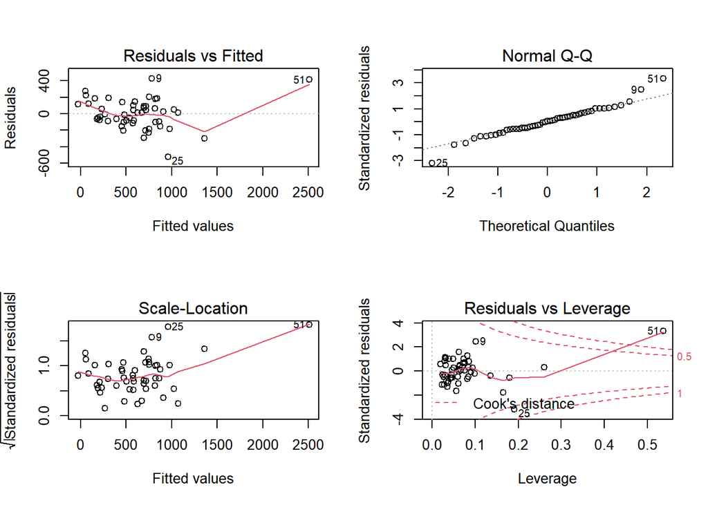

```r
## Leverage versus residuals plot
plot(reg)
```

We see two data points with row numbers 51 and 25 are outside the Cook’s distance which is indicated by two red dashed lines. They need to be checked carefully. As it turns out, row 51 and 25 corresponds to the state, `DC` and `MS`.

```r
## List variables if state == dc or ms: note R is case-sensitive
rstd %>%
  filter(state == "dc" | state == "ms") %>%
  select(sid, state, std.resid, hat, crime, pctmetro, poverty, single)
```

```
#>   sid state std.resid      hat crime pctmetro poverty single
#> 1  51    dc  3.327972 0.536383  2922    100.0    26.4   22.1
#> 2  25    ms -3.193796 0.191012   434     30.7    24.7   14.7
```

**Cook’s Distance**

Let’s move on to Cook’s distance, which combines information on the residual and leverage. The lowest possible value is zero, and the higher the Cook’Distance is, the more influential the point is. The conventional cut-off point is `4 / n`.

Below we list all observations with the Cook’s distance that is greater than `4 / 51`.

```r
## List all variables if Cook's D > 4 / 51
rstd %>%
  filter(cooksd > (4 / 51)) %>%
  select(sid, state, std.resid, cooksd, hat, crime, pctmetro, poverty, single)
```

```
#>   sid state std.resid    cooksd       hat crime pctmetro poverty single
#> 1  18    la -1.793716 0.1592638 0.1652769  1062     75.0    26.4   14.9
#> 2   9    fl  2.470016 0.1736290 0.1022025  1206     93.0    17.8   10.6
#> 3  51    dc  3.327972 3.2034289 0.5363830  2922    100.0    26.4   22.1
#> 4  25    ms -3.193796 0.6021060 0.1910120   434     30.7    24.7   14.7
```

The `DC`’s Cook’s Distance is by far the largest.

**avPlots**

Finally, we create added-variable plots to identify influential points. These are also called partial-regression plots since they help us to evaluate the residuals of a predictor variable while holding the other predictors constant.

Below we use `avPlots` from `car` package.

```r
## Install car pacakage if you don't have it.
install.packages("car")
```

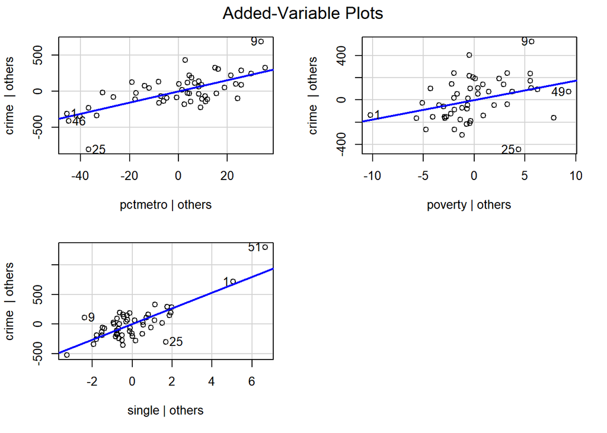

```r
## Create avPlots by inputting our model fit
car::avPlots(fit)
```

In the last `avplot` for single, the graph shows `crime` by `single` after both `crime` and `single` has been adjusted for all other predictors in the model. The line plotted has the same slope as the coefficient for `single`. This plot shows how the observation for `DC` influences the coefficient. You can see how the regression line is tugged upwards trying to fit through the extreme value of `DC` (51). `Alaska` (1) and `West Virginia` (the lowest data point) may also exert substantial leverage on the coefficient of `single`.

```
DC has appeared as an outlier as well as an influential point in every analysis. Since DC is not a state, we can use this to justify omitting it from the analysis saying that we wish to just analyze states.
```

Let’s run `regress` by removing the state `DC`.

```r
## Remove dc row
crime2 <- crime %>%
  filter(state != "dc")

## Fit linear model using dataset with dc row removed
fit <-  lm(crime ~ pctmetro + poverty + single, data = crime2)

## Regression report with 2 decimal points
regress(fit, rnd = 2)
```

```
#> _________________________________________________________________________
#>
#>                 Linear Regression Output
#> _________________________________________________________________________
#>
#>          Stats |    Value             Source |    DF         SS        MS
#>  ------------- + --------         ---------- + ----- ---------- ---------
#>  Number of Obs |       50              Model |     3  3098767.1 1032922.4
#>       F(3, 46) |    39.90           Residual |    46  1190858.1   25888.2
#>       Prob > F |     0.00         ---------- + ----- ---------- ---------
#>      R-Squared |     0.72              Total |    49  4289625.2   87543.4
#>  Adj R-Squared |     0.70
#>            AIC |   655.80                              Root MSE    160.90
#>  ------------- + -------- ------- ------------ ----- ---------- ---------
#>          crime |    Coef. Std.Err            t P>|t| [95% Conf. Interval]
#>  ------------- + -------- ------- ------------ ----- ---------- ---------
#>       pctmetro |     7.71    1.11         6.95  0.00       5.54      9.89
#>        poverty |    18.28    6.14         2.98  0.00       6.26     30.31
#>         single |    89.40   17.84         5.01  0.00      54.44    124.36
#>    (Intercept) | -1197.54  180.49        -6.64  0.00   -1551.29   -843.78
#>  ------------- + -------- ------- ------------ ----- ---------- ---------
#> _________________________________________________________________________
#> (Fit: lm(formula = crime ~ pctmetro + poverty + single, data = crime2))
#> (pctmetro: pct metropolitan)
#> (poverty: pct poverty)
#> (single: pct single parent)
#> (crime: violent crime rate)
```

[^1]: REGRESSION WITH STATA CHAPTER 2 – REGRESSION DIAGNOSTICS. UCLA: Statistical Consulting Group. from https://stats.idre.ucla.edu/stata/webbooks/reg/chapter2/stata-webbooksregressionwith-statachapter-2-regression-diagnostics/ (accessed August 22, 2016)
[^2]: REGRESSION WITH STATA CHAPTER 2 – REGRESSION DIAGNOSTICS. UCLA: Statistical Consulting Group. from https://stats.idre.ucla.edu/stata/webbooks/reg/chapter2/stata-webbooksregressionwith-statachapter-2-regression-diagnostics/ (accessed August 22, 2016)